# Lab 8: Quarter Review + Clustering

Jason Situ

# Dataset: Exoplanet Data

Today’s dataset comes from a NASA database of all known exoplanets.

```r
planets <- read.csv("https://www.dropbox.com/s/2izv8xz6n22hnae/planets2.csv?dl=1")
```

The variables in this dataset are:

```
pl_name:  The name of the planet
pl_hostname: The Solar System of the planet
pl_pnum: The number of planets in the same Solar System
pl_orbper: The orbital period in days
pl_orbsmax: The semi-major axis of orbit
pl_orbeccen: The eccentricity of the orbit
pl_orbincl:  The angle of incline of the orbit
pl_bmassj: The mass of the planet
pl_radj: The radius of the planet
pl_dens: The density of the planet
pl_disc: The year of discovery
pl_discmethod: The method of discovery
pl_facility:  The lab that discovered the planet
pl_locale: Whether the planet was discovered from the ground or from space.
```

Throughout this DA, you may use any built-in R functions you like, rather than calculating quantities from scratch.

## Planet Orbit vs. Size

We might consider grouping these measurements into those that pertain to the size of the planet, and those that pertain to the orbit qualities of the planet, as follows:

```r
planet_orbit <- c("pl_orbper", "pl_orbsmax", "pl_orbeccen", "pl_orbincl")
planet_sizes <- c("pl_bmassj", "pl_radj", "pl_dens")

S_1 = planets %>% dplyr::select(planet_sizes) %>% cov()
S_2 = planets %>% dplyr::select(planet_orbit) %>% cov()
S = planets %>% dplyr::select(planet_sizes, planet_orbit) %>% cov()
U = det(S)/(det(S_1)*det(S_2))
U
```

```
## [1] 0.697
```

Answer the following questions by performing a hypothesis test. For questions where you do not have the tools to calculate a p-value, you do not need to do so. However, you should still state a null and alternate hypothesis, calculate a test statistic, and justify your choice to reject or fail to reject the null based on a discussion of the test statistic.

#### Q1: Is the orbit of a planet is related to its size?

Now let’s calculate the for independence

```r
S_2
```

```
##             pl_orbper pl_orbsmax pl_orbeccen pl_orbincl
## pl_orbper    1349.737    4.65829     0.30912    28.9366
## pl_orbsmax      4.658    0.01675     0.00153     0.1197
## pl_orbeccen     0.309    0.00153     0.01943     0.0345
## pl_orbincl     28.937    0.11973     0.03450     5.5907
```

```r
u = det(S_2)/(1349^2 + .016^2 + .019^2 + 5.59^2)
u
```

```
## [1] 4.13e-08
```

#### Q2: Are the four measures of orbit independent?

Ho: E = E Ho: S = s1 x s2 x s3 xs4 After calculating for indepedences, we get a value of .00 so we reject our null hypothesis and we can conclude that the measure of orbits are not indepedent.

```r
S_1
```

```
##           pl_bmassj pl_radj pl_dens
## pl_bmassj     6.817   0.245   4.938
## pl_radj       0.245   0.191  -0.526
## pl_dens       4.938  -0.526   9.522
```

```r
u = det(S_1)/(6.817^2 + .191^2 + 9.522^2)
u
```

```
## [1] 0.0291
```

#### Q3: Are the three measures of planet size independent?

```
Ho: E=E
Ha: S = s1 x s2 x s3
We get a score of .029, so we reject our null hypothesis and conclude we can conclude that the measure of planet size are not independent.
```

## Discovery of planets by facility

Now consider the variable `pl_facility`, which gives the research station from which the exoplanet was first discovered. The most prolific facilities were Kepler (62), HATSouth (40), and SuperWASP (36). Consider only these facilities. (Code to narrow down the data is provided for you.)

#### Q1: Is there evidence that the three most prolific facilities tend to discover different types of planets, as measured by size and orbit?

Be sure to state your hypotheses, report a test statistic, give a conclusion, and state and discuss your assumptions.

```r
planets_sub = planets %>% filter(pl_facility %in% c("Kepler", "HATSouth", "SuperWASP") )
m =manova(cbind(pl_orbper, pl_orbsmax, pl_orbeccen, pl_orbincl, pl_bmassj, pl_radj, pl_dens)
~ factor(pl_facility), data = planets_sub)
summary(m, test = "Wilks")
```

```
##                      Df Wilks approx F num Df den Df Pr(>F)
## factor(pl_facility)   2 0.385     11.3     14    258 <2e-16 ***
## Residuals           135
## ---
## Signif. codes:  0 '***' 0.001 '**' 0.01 '*' 0.05 '.' 0.1 ' ' 1
```

```r
boxM(cbind(pl_orbper, pl_orbsmax, pl_orbeccen, pl_orbincl, pl_bmassj, pl_radj, pl_dens) ~ factor
(pl_facility), data = planets_sub)
```

```
##
##  Box's M-test for Homogeneity of Covariance Matrices
##
## data:  Y
## Chi-Sq (approx.) = 1000, df = 60, p-value <2e-16
```

[output not shown]

#### Q2: For which planet qualities are the discovering facilities most different?

Support your answer numerically.

```r
planet_data = planets[,c(planet_orbit, planet_sizes)]

lin.disc = lda(planet_data, factor(planets$pl_facility))
sds = apply(planet_data, 2, sd)
first.std.disc = lin.disc$scaling[,1]*sds
first.std.disc
```

```
##   pl_orbper  pl_orbsmax pl_orbeccen  pl_orbincl   pl_bmassj     pl_radj
##     -1.9936      2.5032      0.1540     -0.0596     -0.1335     -0.9050
##     pl_dens
##      0.2385
```

```
From the calculation, we see that the semi-major axis of orbit and orbital period in days are the most different among the facilties.
```

## Discovery location

Suppose we wish to study whether different types of planets were more likely to be discovered from the ground versus from space (`pl_locale`.

```r
planet_data = planets[,c(planet_orbit, planet_sizes)]

planets_ground = planets %>% filter(pl_locale == "Ground") %>% dplyr::select(planet_orbit, planet_sizes)

planets_space = planets %>% filter(pl_locale == "Space") %>% dplyr::select(planet_orbit, planet_sizes)
```

#### Q1: Which variables most explain the difference between planets discovered on the ground versus in space?

```r
ybar1 = colMeans(planets_ground)
ybar2 = colMeans(planets_space)
S1 = cov(planets_ground)
S2 = cov(planets_space)
n1 = nrow(planets_ground)
n2 = nrow(planets_space)
Sp = 1/(n1+n2-2)*((n1-1)*S1 + (n2-1)*S2)
lin.disc.2 = solve(Sp) %*% (ybar1 - ybar2)
sds = apply(planet_data, 2, sd)
sds
```

```
##   pl_orbper  pl_orbsmax pl_orbeccen  pl_orbincl   pl_bmassj     pl_radj
##      36.739       0.129       0.139       2.364       2.611       0.437
##     pl_dens
##       3.086
```

```r
std.disc = lin.disc.2*sds
std.disc
```

```
##                [,1]
## pl_orbper    3.8938
## pl_orbsmax  -4.7814
## pl_orbeccen -0.0366
## pl_orbincl   0.1293
## pl_bmassj   -0.1291
## pl_radj      1.2595
## pl_dens     -0.1531
```

```
From the calculaton above, we see that again the orbital period in days and semi-major axis of orbit have the most difference when comparing planets discovered on the ground vs in space.
```

#### Q2: Do you think the following planet is more likely to have been discovered from the ground or from space? Why?

```r
new_planet = c(10.8, 0.09, 0.08, 86.5, 1.3, 0.72, 1.4)
score = t(lin.disc.2) %*% new_planet
g = t(lin.disc.2) %*% ybar1
s = t(lin.disc.2) %*% ybar2
g
```

```
##      [,1]
## [1,] 6.84
```

```r
s
```

```
##      [,1]
## [1,] 4.38
```

```r
score
```

```
##      [,1]
## [1,] 4.47
```

```
Since our calculation closer to the mean of the space data, we would have to say the new planets was discovered from space.
```

## Clustering

Suppose we now wish to group our planets according to their orbitals and sizes, and see how well this groups planets by their location of discovery.

#### Q1: Perform hierarchical clustering on the data, and plot the dendrogram. Label the observations by your choice of factor variable (hostname, pnum, disc, facility, discmethod, or locale). How well does this unsupervised clustering line up with the groups of the factor variable?

```r
hier = hclust(dist(planets))
```

[figure not shown]

```
Using pl_local(location of discovery), the dendrogram isn't really a good visual help and hard to tell the clusters apart.
```

```r
plot(hier, label = planets$pl_local)
```

#### Q2: Perform a k-means clustering on your choice of Principal Components of the data, with k = 2. Discuss how well the unsupervised clustering separated planets by their location of discovery.

```r
pca = prcomp(planet_data, center = TRUE, scale = TRUE)
pca
```

```
## Standard deviations (1, .., p=7):
## [1] 1.573 1.277 1.045 0.996 0.802 0.393 0.126
##
## Rotation (n x k) = (7 x 7):
##                 PC1     PC2    PC3     PC4     PC5     PC6     PC7
## pl_orbper    0.5634  0.0802 -0.348  0.2335  0.1218 -0.0697 -0.6932
## pl_orbsmax   0.5766  0.0878 -0.328  0.1891  0.0641  0.0926  0.7096
## pl_orbeccen  0.0847 -0.0732 -0.369 -0.8928  0.2309  0.0188 -0.0161
## pl_orbincl   0.4050  0.0404  0.283 -0.2924 -0.8040 -0.1453 -0.0335
## pl_bmassj   -0.0731 -0.6858 -0.297  0.1042 -0.3136  0.5679 -0.0666
## pl_radj     -0.3820  0.1019 -0.662  0.1202 -0.3769 -0.4956  0.0581
## pl_dens      0.1661 -0.7058  0.167  0.0421  0.2022 -0.6300  0.0824
```

```r
vars_transformed <- apply(pca$x, 2, var)
vars_transformed
```

```
##    PC1    PC2    PC3    PC4    PC5    PC6    PC7
## 2.4728 1.6298 1.0920 0.9913 0.6437 0.1544 0.0159
```

```r
vars_transformed/sum(vars_transformed)
```

```
##     PC1     PC2     PC3     PC4     PC5     PC6     PC7
## 0.35326 0.23282 0.15601 0.14161 0.09196 0.02206 0.00227
```

```
We can see that PC1 and PC2 give us a 35% variation and 23% variation respectively and if we include PC3, we would get around a 75% variation.
```

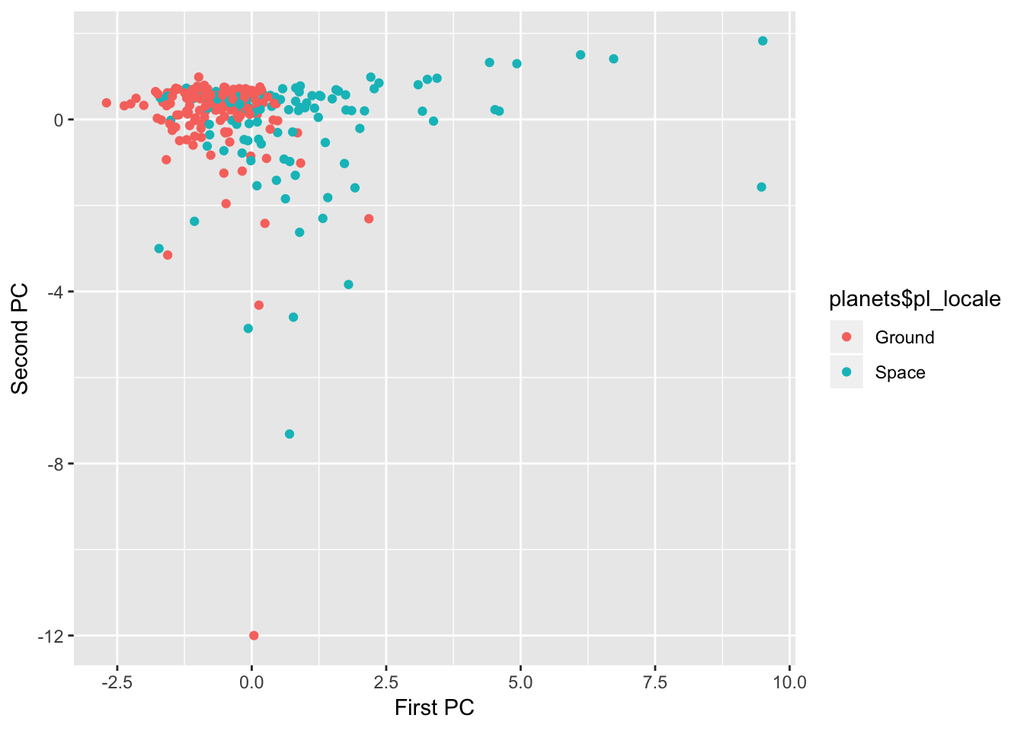

```r
ggplot(, aes(x = pca$x[,1], y = pca$x[,2], col = planets$pl_locale)) +
geom_point() + xlab("First PC") +
ylab("Second PC")
```

```r
km = kmeans(pca$x[,1:4], centers = 2)
planets$pl_locale[km$cluster == 1]
```

```
##   [1] Space  Space  Space  Space  Space  Space  Space  Space  Space  Space
##  [11] Space  Space  Space  Space  Space  Space  Space  Space  Space  Space
##  [21] Space  Space  Ground Ground Ground Ground Ground Ground Ground Ground
##  [31] Ground Ground Ground Ground Ground Ground Ground Ground Ground Ground
##  [41] Ground Ground Ground Ground Ground Ground Ground Ground Ground Ground
##  [51] Ground Ground Ground Ground Ground Ground Ground Ground Ground Ground
##  [61] Ground Ground Ground Ground Ground Ground Ground Ground Ground Ground
##  [71] Ground Ground Ground Ground Ground Ground Ground Ground Ground Ground
##  [81] Ground Ground Ground Ground Ground Ground Ground Ground Ground Ground
##  [91] Ground Ground Space  Space  Space  Space  Space  Space  Space  Space
## [101] Space  Space  Space  Space  Space  Space  Ground Ground Ground Ground
## [111] Ground Ground Ground Ground Space  Space  Space  Ground Space  Space
## [121] Space  Space  Space  Space  Space  Space  Space  Space  Space  Space
## [131] Space  Space  Space  Space  Space  Space  Space  Space  Space  Space
## [141] Space  Space  Space  Space  Space  Space  Space  Space  Space  Space
## [151] Space  Space  Space  Space  Ground Ground Ground Ground Ground Ground
## [161] Ground Ground Ground Ground Ground Ground Ground Ground Ground Ground
## [171] Ground Ground Ground Ground Ground Ground Ground Ground Ground Ground
## [181] Ground Ground Ground Ground Ground Ground Ground Ground Ground Ground
## [191] Ground Ground Ground Ground Ground Ground Ground Ground Ground Ground
## [201] Space  Space  Ground Ground Ground Ground Ground Ground Ground Ground
## [211] Ground Ground Ground Ground Ground Space  Ground Ground Ground Ground
## [221] Ground Ground Ground Ground Ground Ground
## Levels: Ground Space
```

```r
planets$pl_locale[km$cluster == 2]
```

```
##  [1] Space  Space  Space  Ground Space  Space  Space  Ground Space  Space
## [11] Space  Space  Space  Space  Space  Space  Space  Space  Space  Space
## [21] Space  Space  Space  Space  Space  Space  Space  Space  Space  Space
## [31] Space  Ground
## Levels: Ground Space
```

[output not shown]

```r
km
```

```
## K-means clustering with 2 clusters of sizes 226, 32
##
## Cluster means:
##      PC1    PC2     PC3      PC4
## 1 -0.416  0.162  0.0779 -0.00484
## 2  2.939 -1.143 -0.5502  0.03415
##
## Clustering vector:
##   [1] 1 1 1 1 1 1 1 1 1 1 2 1 1 1 1 1 1 2 1 1 1 1 1 1 2 1 1 1 1 1 1 2 1 1 1
##  [36] 1 1 1 1 1 1 1 1 1 1 1 1 1 1 1 1 1 1 1 1 1 1 1 1 1 1 1 1 1 1 1 1 1 1 1
##  [71] 1 1 1 1 1 1 1 1 1 1 1 1 1 1 1 1 1 1 1 1 1 1 1 1 1 1 1 2 1 1 1 1 1 1 1
## [106] 1 2 1 2 1 1 1 1 2 1 1 1 1 1 1 1 1 2 1 2 1 1 2 1 1 1 1 1 1 1 2 2 1 2 1
## [141] 2 1 1 1 1 1 1 1 2 1 2 2 2 2 2 1 2 1 1 1 2 1 1 1 1 1 2 1 1 1 1 1 1 2 2
## [176] 1 1 2 1 1 1 2 2 2 2 2 1 1 1 1 1 1 1 1 1 1 1 1 1 1 1 1 1 1 1 1 1 1 1 1
## [211] 1 1 1 1 1 1 1 1 1 1 1 1 1 1 1 1 1 1 1 1 1 1 1 1 1 1 1 1 1 1 1 1 1 1 1
## [246] 1 1 1 1 1 1 1 1 1 1 1 1 1
##
## Within cluster sum of squares by cluster:
## [1] 596 619
##  (between_SS / total_SS =  23.5 %)
##
## Available components:
##
## [1] "cluster"      "centers"      "totss"        "withinss"
## [5] "tot.withinss" "betweenss"    "size"         "iter"
## [9] "ifault"
```